# KI_RIKEN_Course_2023

Fenix Pan

2023-10-10

## Assignment 1

### Task 1 ❱❱❱

1. **Read the research article of the hands-on working group you are assigned to.**  
   ► Mobile element variation contributes to population-specific genome diversification, gene regulation and disease risk  
   https://www.nature.com/articles/s41588-023-01390-2
2. **Answer the following questions**

   **🄰 What is the medically relevant insight from the article?**

   **🄱 Which genomics technology/technologies were used?**

   ► NGS: WGS, GTEx, Amplicon-Seq  
   ► Bioinformatics: eQTL
3. **Further related research questions**

   **🄰 List and explain at least three questions/hypotheses you can think of that extend the analysis presented in the paper.**

   ► The hotspot of ME  
   ►  
   ►

   🄱 [Optional] Devise a computational analysis strategy for (some of) the listed questions under 3a.

### Task 2 ❱❱❱

- Start a new project in a Gitlab, Github or Figshare repository. Check with your doctoral supervisor if you can start a project in the repository of your lab or if you have to start your own repository.
- All documentation of the Assignment 1 has to be provided in your Git/Figshare repository as a (formatted) text document.
- All documentation of your hands-on work during Week 2 also has to be provided in your repository as R Markdown/ Jupyter Notebook document(s).

  ► Done

  Some references for Rmarkdown
  - quick ref 1 https://raw.githubusercontent.com/rstudio/cheatsheets/main/rmarkdown-2.0.pdf
  - quick ref 2 https://www.rstudio.com/wp-content/uploads/2015/02/rmarkdown-cheatsheet.pdf

### Task 3 ❱❱❱

- Install the most recent version of the R software on your computer by following the instructions provided at the R software website.
- Install the most recent version of RStudio Desktop (Open Source version) on your computer.
- Bioconductor is an add-on package for R providing tools for the analysis and comprehension of high-throughput genomic data. Install the most recent version of the Bioconductor package on your computer.
- Tidyverse is a toolbox for streamlining data import, modeling, transformation, curation, and visualization. Tidyverse tools enable you to make your scripts more reader friendly and overall more neat and efficient. https://www.tidyverse.org/packages/
  - Tidyverse has a powerful visualization package called ggplot2 that we recommend using. With ggplot2, you have more control over your plot’s parameters than with the basic R plotting functions. https://ggplot2.tidyverse.org/#learning-ggplot2
- [Optional] Conduct the R online course available here:
  - Introduction to R (hands-on exercises, strongly encouraged) https://campus.datacamp.com/courses/free-introduction-to-r (the course is completely free, but asks after every completed level to sign up for a license, which can be circumvented by going back to the course list)
- Alternative resources for R https://www.datacamp.com/community/open-courses/r-for-the-intimidated
- R also provides an internal learning package named Swirl. Swirl is interactive and gives feedback on your progress. https://swirlstats.com/ Depending on your previous experiences with R, taking this R online course might take more or less time. Please make sure to understand the concepts behind the exercises.
- [Optional] You can consider using R-notebooks for Assignment 1. It is up to your preferences.
- Reference for R language https://cran.r-project.org/doc/manuals/r-release/R-intro.pdf
- [Optional] More information on R Markdown and the Markdown cheatsheet https://rmarkdown.rstudio.com https://raw.githubusercontent.com/rstudio/cheatsheets/master/rmarkdown-2.0.pdf (opening the link will download the cheat sheet on your computer)

### Task 4 ❱❱❱

1. **Use the R internal CO2 dataset (“data(CO2)”).**  
   `data(CO2)`
2. **Describe briefly the content of the CO2 dataset using the help function.**  
   `help(CO2)`

   ► The CO2 data frame has 84 rows and 5 columns of data from an experiment on the cold tolerance of the grass species Echinochloa crus-galli.  
   ► The columns include
   - “Plant” ➜ the sampling individuals
   - “Type” ➜ the original of the plant: Quebec | Mississippi
   - “Treatment” ➜ the experimental treatment: nonchilled | chilled
   - “conc” ➜ ambient CO2 concentration (mL/L)
   - “uptake” ➜ CO2 uptake rates (umol/m2 sec)
3. **What is the average and median CO2 uptake of the plants from Quebec and Mississippi?**  
   For the plants from Quebec:

   ```r
   # Use subset function to grep the row where
   # the "Type" column is Quebec/Mississippi and return the value of "uptake" column.
   # The return is a "list", transfer it to "matrix" to be calculated.
   # Use mean/median functions to calculate an one-column matrix of "uptake" values of selected rows.
     mean(as.matrix(subset(CO2, Type == "Quebec", uptake)))    # Average
   ```

   ```
   ## [1] 33.54286
   ```

   ```r
     median(as.matrix(subset(CO2, Type == "Quebec", uptake)))  # Median
   ```

   ```
   ## [1] 37.15
   ```

   ```r
     mean(as.matrix(subset(CO2, Type == "Mississippi", uptake)))    # Average
   ```

   ```
   ## [1] 20.88333
   ```

   ```r
     median(as.matrix(subset(CO2, Type == "Mississippi", uptake)))  # Median
   ```

   ```
   ## [1] 19.3
   ```

4. [Optional] In the “airway” example data from Bioconductor, how many genes are expressed in each sample?  
   How many genes are not expressed in any sample?

   # Install the “airway” example data from Bioconductor  
   `install.packages(BiocManager)`  
   `BiocManager::install(airway)`  
   `library(BiocManager)`  
   # Import the dataset  
   `data(airway)`

[Not Done Yet]

### Task 5 ❱❱❱

1. Write a function that calculates the ratio of the mean and the median of a given vector.  
   This is a helpful measure to detect data with outlying values.  
   Note: See Reference for R language

   ```r
   MEAN2MEDIAN <- function(x) {
     ratio = mean(x)/median(x)
     ratio
   }
   ```

   Test Run:

   ```r
   library("fGarch")  # Library to generate a skewed dataset
   ```

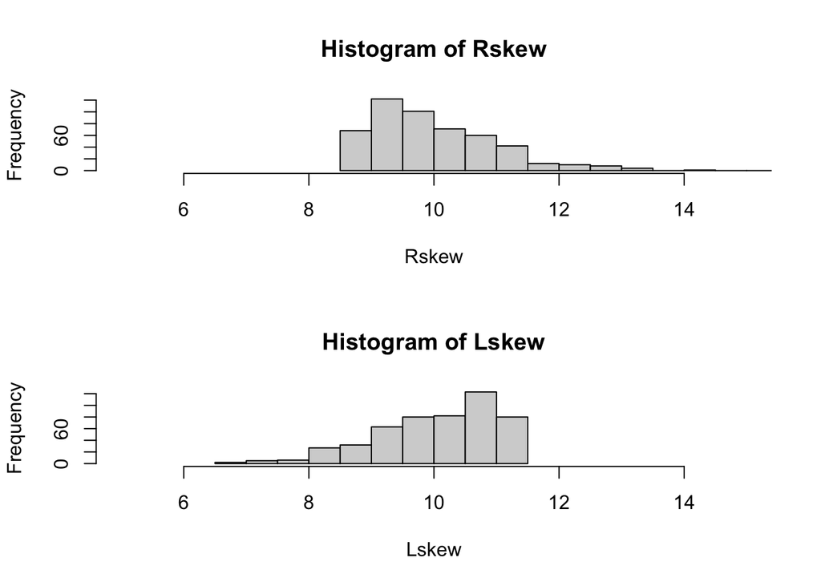

   ```r
   Rskew <- rsnorm(500, mean = 10, sd = 1, xi =  5)
   Lskew <- rsnorm(500, mean = 10, sd = 1, xi = -5)
   par(mfrow = c(2,1))
   Rhist <- hist(Rskew, xlim = c(5,15))
   Lhist <- hist(Lskew, xlim = c(5,15))
   ```

   ```r
   MEAN2MEDIAN(Rskew)  # > 1  (> 0 when mean = 0)
   ```

   ```
   ## [1] 1.025226
   ```

   ```r
   MEAN2MEDIAN(Lskew)  # < 1  (< 0 when mean = 0)
   ```

   ```
   ## [1] 0.9816769
   ```

2. Write a function that ignores the lowest and the highest value from a given vector and calculate the mean.

   ```r
   adjMEAN <- function(x) {
     sort_x <- sort(x)                  # Sort vector
     sort_x <- sort_x[-1]               # Remove the lowest value
     sort_x <- sort_x[-length(sort_x)]  # Remove the highest value
     mean(sort_x)                       # Calculate the mean
   }
   ```

   Test Run:

   ```r
   mean(Rskew)     # Original mean
   ```

   ```
   ## [1] 10.01177
   ```

   ```r
   adjMEAN(Rskew)  # Mean after removal of the lowest and highest values.
   ```

   ```
   ## [1] 10.00348
   ```

   ```r
   mean(Lskew)     # Original mean
   ```

   ```
   ## [1] 10.04547
   ```

   ```r
   adjMEAN(Lskew)  # Mean after removal of the lowest and highest values.
   ```

   ```
   ## [1] 10.04986
   ```

3. Read about piping from here: https://r4ds.had.co.nz/pipes.html#pipes (you don’t have to learn everything, a basic understanding of the usage is enough). Write a short (max. 300 characters, no spaces) explanation of why, how, and when not to use pipes.

   **TBD**
4. Familiarize yourself with the apply-family of functions (apply, lapply, sapply etc.) http://uc-r.github.io/apply_family Write a short explanation (max. 300 characters, no spaces) of why they could be useful in your work.

   **TBD**

### Task 6 ❱❱❱

Comment: Files are provided in the shared Google Drive folder under Course week 1.  
Examples of how to use visualization functions in R and other highly useful information that may aid you during the course can be found here https://guardacaccia.github.io/Teaching/  
The nummenmaa-package mentioned within the examples can be installed with the code below if you wish to try some of the examples yourself.

`install.packages("remotes")`  
`library(remotes)`  
`install_url("http://emotion.utu.fi/wp-content/uploads/2019/11/nummenmaa_1.0.tar.gz",dependencies=TRUE)`

1. **Compare the distributions of the body heights of the two species from the ‘magic_guys.csv’ dataset graphically.**

   **🄰 Using the basic ‘hist’ function as well as ‘ggplot’ and ‘geom_histogram’ functions from the ggplot2 package. Optimize the plots for example by trying several different ‘breaks’.** Note that ggplot2-based functions give you many more options for changing the visualization parameters, try some of them.

   ```r
   TASK6 <- read.csv(file="/Users/fp/Downloads/magic_guys.csv", header = TRUE, row.names = 1)
   ```

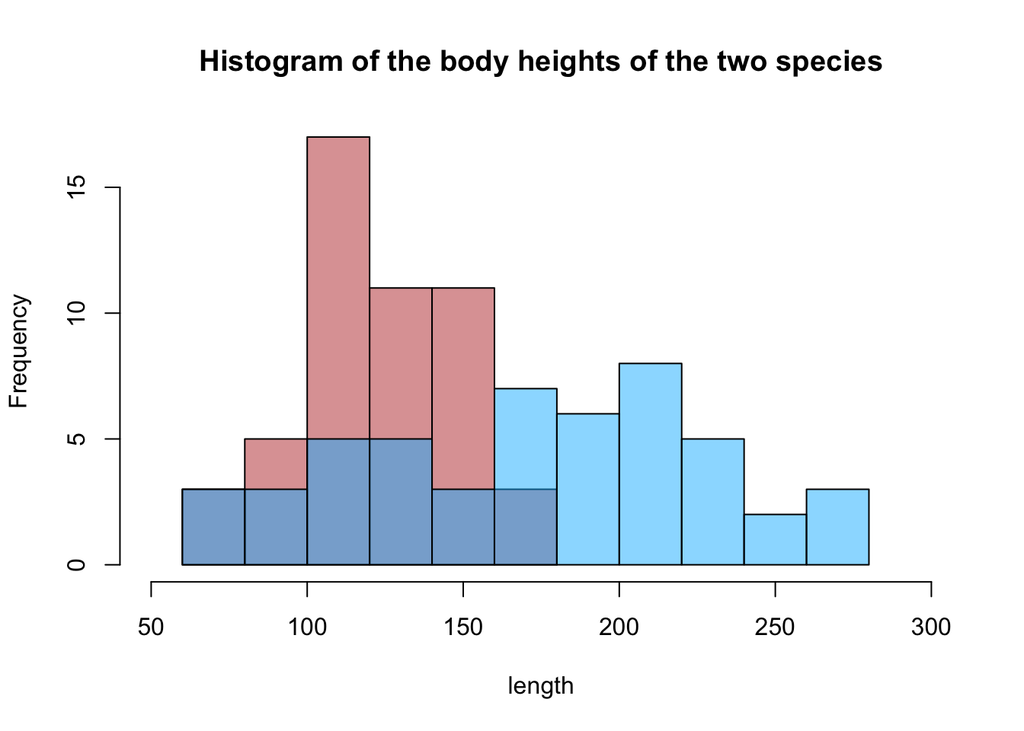

   ```r
   # Histogram by basic hist function (Smaller "breaks")
   hist(TASK6$length[TASK6$species == "sith"], breaks =  5, col = "#BB33337F", xlim = c(50,300), main = "Histogram of the body heights of the two species", xlab = "length")
   hist(TASK6$length[TASK6$species == "jedi"], breaks = 10, col = "#00BBFF7F", xlim = c(50,300), add = TRUE, main = "", xlab = "")
   ```

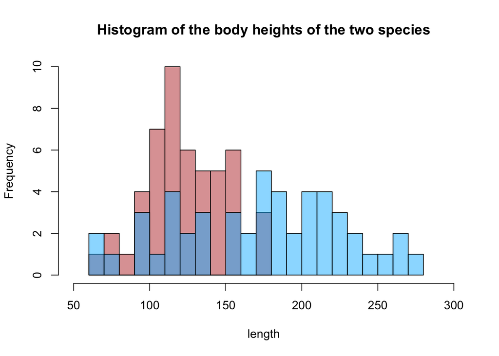

   ```r
   # Histogram by basic hist function (Optimal "breaks")
   hist(TASK6$length[TASK6$species == "sith"], breaks = 10, col = "#BB33337F", xlim = c(50,300), main = "Histogram of the body heights of the two species", xlab = "length")
   hist(TASK6$length[TASK6$species == "jedi"], breaks = 20, col = "#00BBFF7F", xlim = c(50,300), add = TRUE, main = "", xlab = "")
   ```

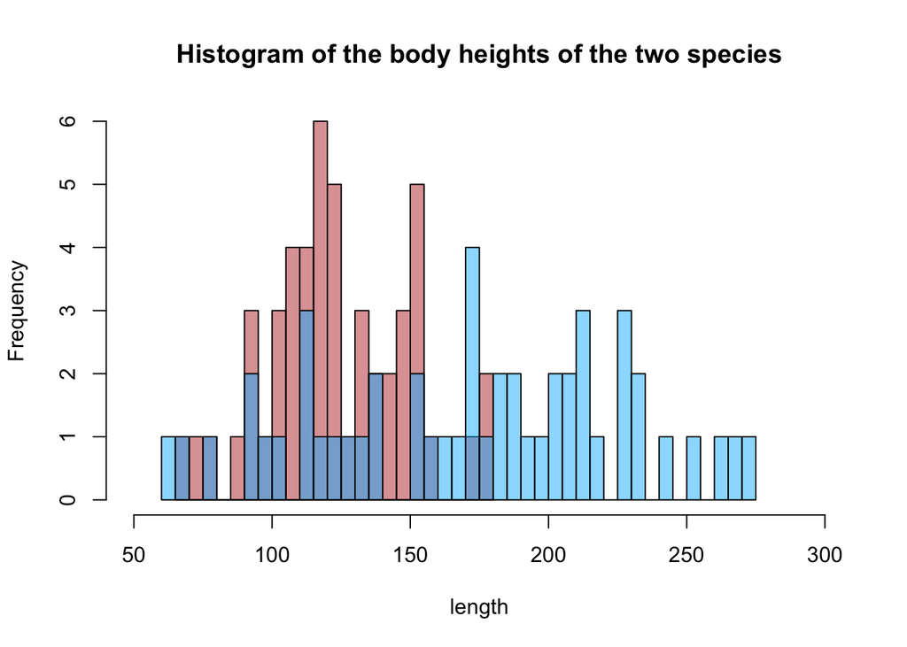

   ```r
   # Histogram by basic hist function (Bigger "breaks")
   hist(TASK6$length[TASK6$species == "sith"], breaks = 20, col = "#BB33337F", xlim = c(50,300), main = "Histogram of the body heights of the two species", xlab = "length")
   hist(TASK6$length[TASK6$species == "jedi"], breaks = 40, col = "#00BBFF7F", xlim = c(50,300), add = TRUE, main = "", xlab = "")
   ```

   ```r
   library(ggplot2)  # Import ggplot2
   ```

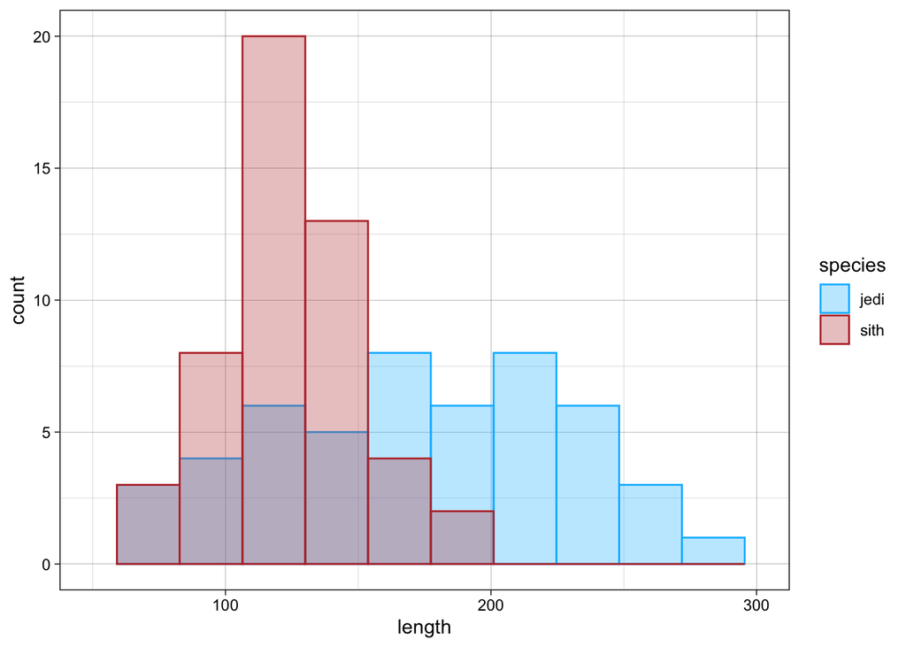

   ```r
   # Histogram by ggplot2 (Smaller "breaks")
     ggplot(TASK6, aes(x=length, fill=species, color=species)) +
     geom_histogram(alpha=0.3, position="identity", bins = 10) +
     scale_fill_manual(values=c("#00BBFF","#BB3333")) +
     scale_color_manual(values=c("#00BBFF","#BB3333")) +
     coord_cartesian(xlim = c(50,300)) +
     theme_linedraw() +
     xlab("length")
   ```

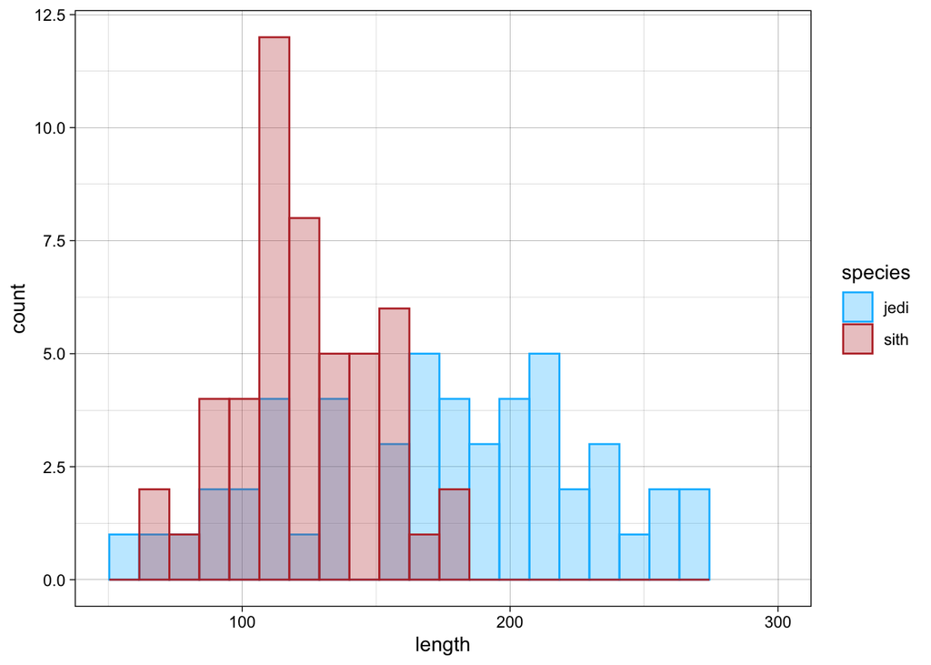

   ```r
   # Histogram by ggplot2 (Optimal "breaks")
     ggplot(TASK6, aes(x=length, fill=species, color=species)) +
     geom_histogram(alpha=0.3, position="identity", bins = 20) +
     scale_fill_manual(values=c("#00BBFF","#BB3333")) +
     scale_color_manual(values=c("#00BBFF","#BB3333")) +
     coord_cartesian(xlim = c(50,300)) +
     theme_linedraw() +
     xlab("length")
   ```

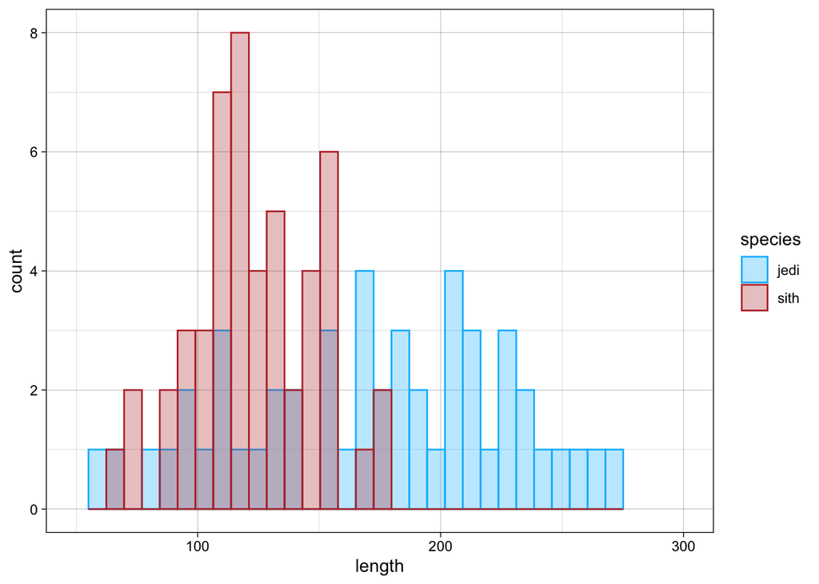

   ```r
   # Histogram by ggplot2 (Bigger "breaks")
     ggplot(TASK6, aes(x=length, fill=species, color=species)) +
     geom_histogram(alpha=0.3, position="identity", bins = 30) +
     scale_fill_manual(values=c("#00BBFF","#BB3333")) +
     scale_color_manual(values=c("#00BBFF","#BB3333")) +
     coord_cartesian(xlim = c(50,300)) +
     theme_linedraw() +
     xlab("length")
   ```

   **🄱 Do the same comparison as in 🄰 but with boxplots. If you want to use the ggplot2-package, use the functions ‘ggplot’ and ‘geom_boxplot’.**

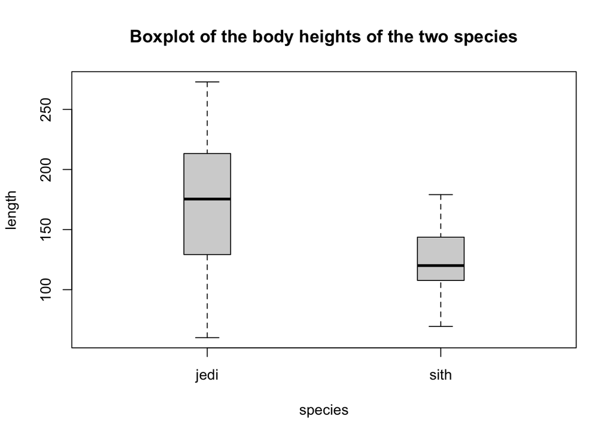

   ```r
   boxplot(TASK6$length~TASK6$species,
   main="Boxplot of the body heights of the two species",
   xlab="species", ylab="length", boxwex=0.2)
   ```

   **🄲 Save the plots with the ‘png’, ‘pdf’, and ‘svg’ formats. In which situation would you use which file format?**

   ► Done (export and save at laptop locally)
   - png ➜ Raster image (fixed pixels). Suitable for web-pages, slides, screen view. It becomes blurry if enlarged.
   - pdf ➜ Vector document. Suitable for file transfer and keeps the same view of fonts on the device which doesn’t have the same fonts.
   - svg ➜ Vector illustration. Suitable for editing, layout and embed into other files. It keeps clear and sharp when resize.
2. **Load the gene expression data matrix from the ‘microarray_data.tab’ dataset provided in the shared folder, it is a big tabular separated matrix.**

   **🄰 How big is the matrix in terms of rows and columns?**

   ```r
   ARRAY<-read.table(file="~/Downloads/microarray_data.tab",header=TRUE,sep="\t")
   dim(ARRAY)  # Get the dimension of the array ➜ 553 rows, 1000 cols
   ```

   ```
   ## [1]  553 1000
   ```

   **🄱 Count the missing values per gene and visualize this result.**

   ```r
   NAs <- sapply(ARRAY, function(x) sum(is.na(x)))
   # In this case, the "sapply" is for "per-column loop", and sum the number of cols with NA
   summary(NAs)
   ```

   ```
   ##    Min. 1st Qu.  Median    Mean 3rd Qu.    Max.
   ##     2.0    23.0    60.0   117.8   196.2   553.0
   ```

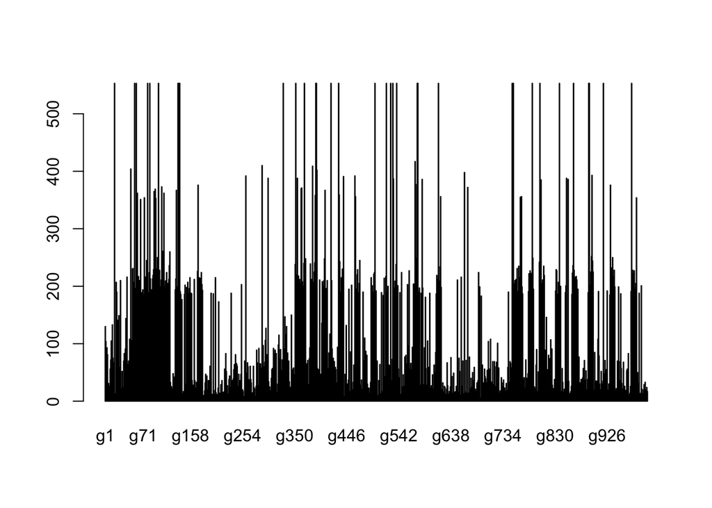

   ```r
   # Option[1]
   # Use barchart to visualize the genes with missing values by "gene order".
   # ➜ If the order of genes is meaningful (e.g. chromosomal coordinates)
   barplot(sapply(ARRAY, function(x) sum(is.na(x))))
   ```

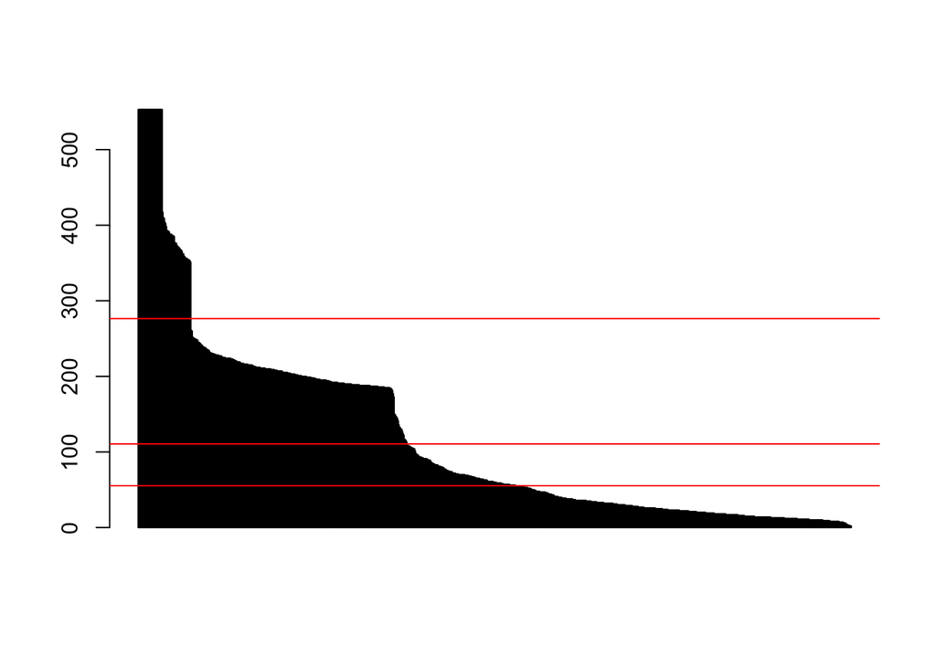

   ```r
   # Option[2]
   # Use barchart to visualize the genes with missing values by "the order of ranked values".
   # ➜ Could visualize the potential cutoffs. X-axis has no meaningful.
   barplot(sort(sapply(ARRAY, function(x) sum(is.na(x))),decreasing=TRUE),xaxt="n")
   # xaxt = "n" to remove x-values on the figure
   abline(h=276.5,col="red")  # 50% cutoff line
   abline(h=110.6,col="red")  # 20% cutoff line
   abline(h= 55.3,col="red")  # 10% cutoff line
   ```

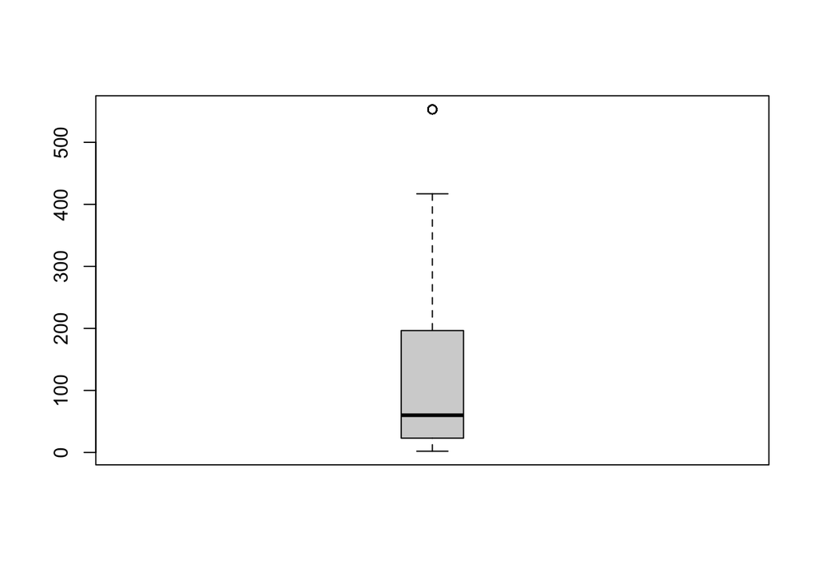

   ```r
   # Option[3]
   # ➜ Use boxplot to visualize the genes with missing values if the distribution of cut off is meaningful.
   boxplot(sapply(ARRAY, function(x) sum(is.na(x))), boxwex = 0.2)
   ```

   **🄲 Find the genes for which there are more than X% (X=10%, 20%, 50%) missing values.**

   ```r
   library(tidyverse)
   # Calculate the number of NAs per columns and report to a one col matrix
   NAs <- as.data.frame(sapply(ARRAY, function(x) sum(is.na(x))))
   # Convert the value to percentage
   pct_NAs <- as.data.frame(sapply(NAs, function(x) x/553))
   # Add the rowname (= gene name)
   rownames(pct_NAs)<-colnames(ARRAY)
   # Add the colname (= pct)
   colnames(pct_NAs)<-"pct"
   # Print how many genes whose missing values are more than X%
   # To get the full gene list, remove the length() function
   length(rownames(filter(pct_NAs,pct >= 0.1)))
   ```

   ```
   ## [1] 529
   ```

   ```r
   length(rownames(filter(pct_NAs,pct >= 0.2)))
   ```

   ```
   ## [1] 377
   ```

   ```r
   length(rownames(filter(pct_NAs,pct >= 0.5)))
   ```

   ```
   ## [1] 74
   ```

   **🄳 Replace the missing values by the average expression value for the particular gene. (Note: Imputing data has to be used with caution!)**

   ```r
   # A function that replaces the NA fields by the mean of a given vector
   # The given vector can be either cols or rows, it is col in this case
   NA2MEAN <- function(x) {
   x[is.na(x)] <- mean(x,na.rm=TRUE)
   x
   }

   # Use sapply to make a loop for each column (each gene)
   ARRAY_noNAs <- sapply(ARRAY,function(x) NA2MEAN(x))
   ```

3. **Visualize the data in the CO2 dataset in a way that gives you a deeper understanding of the data. What do you see?**

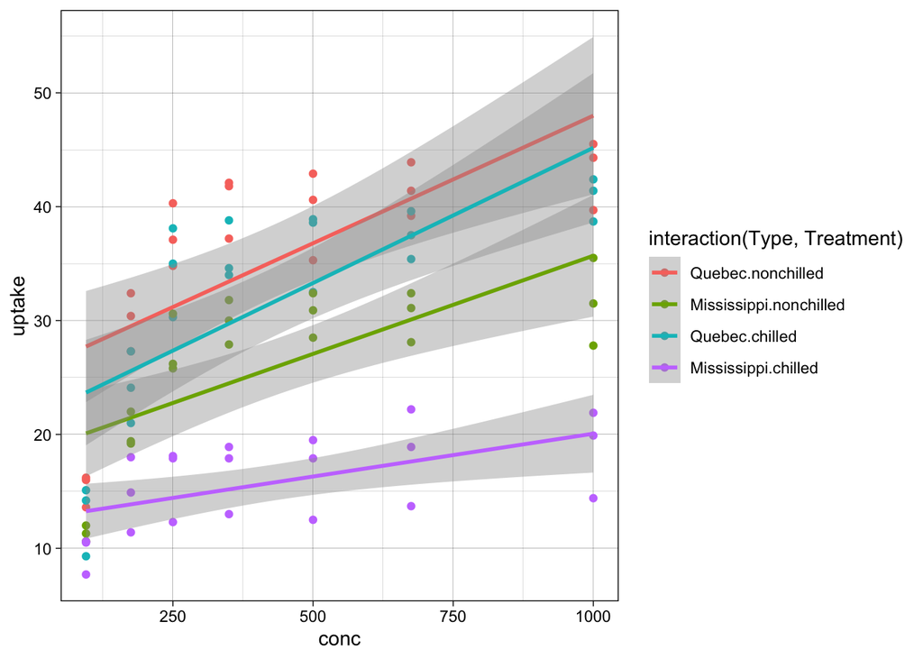

   ```r
   ggplot(CO2, aes(x = conc, y = uptake,
               group = interaction(Type,Treatment),
               color = interaction(Type,Treatment))) +
               geom_point() +
               stat_smooth(method="lm") +
               theme_linedraw()
   ```

   In general, ambient CO2 concentration is assosiated with CO2 uptakes, higer the CO2 concentration, higher the CO2 uptakes.  
   ➜ The regressions are concordant across subsets.  
   For the plants from the same origin, its CO2 uptake efficiency is higher in nonchilled than chilled treatments.  
   ➜ The regressions of orange/green are higher than the regressions of blue/purple.  
   No matter what treatments, the CO2 uptake efficiency is higher for the plants from Quebec than from Mississippi.  
   ➜ The CO2 uptake efficiency is better in the plants from the environemnt with lower temperature climate.

### Task 7 ❱❱❱

1. Install the Tidybiology package, which includes the data ‘chromosome’ and ‘proteins’ `devtools::install_github("hirscheylab/tidybiology")`
1. Extract summary statistics (mean, median and maximum) for the following variables from the ‘chromosome’ data: variations, protein coding genes, and miRNAs. Utilize the tidyverse functions to make this as simply as possible.
2. How does the chromosome size distribute? Plot a graph that helps to visualize this by using ggplot2 package functions.
3. Does the number of protein coding genes or miRNAs correlate with the length of the chromosome? Make two separate plots to visualize these relationships.
4. Calculate the same summary statistics for the ‘proteins’ data variables length and mass. Create a meaningful visualization of the relationship between these two variables by utilizing the ggplot2 package functions. Play with the colors, theme- and other visualization parameters to create a plot that pleases you.

## Assignment 2

You are commenting on the Assignment 1 of a fellow course participant considering the criteria below and send your comments directly to the fellow student.

The member to be commented ➜ **Yubo ZHANG** https://github.com/pks-fxbnl/2023.10_RIKEN_KI_Assignment-1

1. **Format of the assignment**

   **🄰 Is the assignment well structured?**

   **🄱 Is the formatting appropriate?**
2. **Completeness of the assignment**

   **🄰 Are all the tasks addressed?**
3. **Correctness of the answers**

   **🄰 Are the given answers correct to the best of your understanding?**
4. Validity of the drawn conclusions
1. Do the provided analyses address the questions asked?
2. Are the provided insights conclusive given the conducted analyses?
5. Style of the written R code
1. Is the provided R code well documented?